This chapter will include the following topics: • Tokenization of text • Normalization of text • Substituting and correcting tokens • Applying Zipf's law to text • Applying similarity measures using the Edit Distance Algorithm • Applying similarity measures using Jaccard's Coefficient • Applying similarity measures using Smith Waterman

```python
import warnings
warnings.filterwarnings('ignore')
```

# Tokenization

Tokenization may be defined as the process of splitting the text into smaller parts called tokens, and is considered a crucial step in NLP.

### Tokenization of text into sentences

```python
import nltk
text=" Welcome readers. I hope you find it interesting. Please do reply."
```

```python
from nltk.tokenize import sent_tokenize
sent_tokenize(text)    # Uses PunktSentenceTokenizer for tokenizing.
```

```
[' Welcome readers.', 'I hope you find it interesting.', 'Please do reply.']
```

```python
import nltk
tokenizer=nltk.data.load('tokenizers/punkt/english.pickle')
```

```python
text="Welcome readers. I hope you find it interesting. Please do reply."
tokenizer.tokenize(text)   # We can load PunktSentenceTokenizer and use the tokenize() function.
```

```
['Welcome readers.', 'I hope you find it interesting.', 'Please do reply.']
```

### Tokenization of text in other languages

```python
import nltk
french_tokenizer=nltk.data.load('tokenizers/punkt/french.pickle')
```

```python
french_tokenizer.tokenize("""Deux agressions en quelques jours,voilà ce qui a motivé hier matin le débrayage collège francobritanniquedeLevallois-Perret. Deuxagressions en quelques jours,voilà ce qui a motivé hier matin le débrayage Levallois. Léquipepédagogique de ce collège de 750 élèves avait déjà été choquéepar l'"agression, janvier , d'un professeur d'histoire. L'équipepédagogique de ce collège de 750 élèves avait déjà été choquée parl'agression, mercredi , d'un professeur d'histoire""")
```

```
['Deux agressions en quelques jours,voilà ce qui a motivé hier matin le débrayage collège francobritanniquedeLevallois-Perret.',
 'Deuxagressions en quelques jours,voilà ce qui a motivé hier matin le débrayage Levallois.',
 'Léquipepédagogique de ce collège de 750 élèves avait déjà été choquéepar l\'"agression, janvier , d\'un professeur d\'histoire.',
 "L'équipepédagogique de ce collège de 750 élèves avait déjà été choquée parl'agression, mercredi , d'un professeur d'histoire"]
```

### Tokenization of sentences into words

```python
text=nltk.word_tokenize("PierreVinken , 59 years old , will joinas a nonexecutive director on Nov. 29")
print(text) # word_tokenize function uses an instance of NLTK known as TreebankWordTokenizer.
```

```
['PierreVinken', ',', '59', 'years', 'old', ',', 'will', 'joinas', 'a', 'nonexecutive', 'director', 'on', 'Nov.', '29']
```

```python
type(text)
```

```
list
```

```python
from nltk import word_tokenize
r=input("Please write a text")
print("The length of text is",len(word_tokenize(r)),"words")
```

```
Please write a texthello everyone how are you??
The length of text is 7 words
```

### Tokenization using TreebankWordTokenizer

```python
from nltk.tokenize import TreebankWordTokenizer
tokenizer = TreebankWordTokenizer()
result = tokenizer.tokenize("Don't hesitate to ask questions")
result
```

```
['Do', "n't", 'hesitate', 'to', 'ask', 'questions']
```

```python
type(result)
```

```
list
```

```python
from nltk.tokenize import WordPunctTokenizer
tokenizer=WordPunctTokenizer()
tokenizer.tokenize(" Don't hesitate to ask questions")
```

```
['Don', "'", 't', 'hesitate', 'to', 'ask', 'questions']
```

# Types of Tokenizers

```
                                 Tokenizer

      PunktWord Tokenizer        Regex Tokenizer                         TreeBank Tokenizer
                               - WordPunct Tokenizer
                               - Whitespace Tokenizer
```

### Tokenization using regular expressions

```python
import nltk
from nltk.tokenize import RegexpTokenizer
from nltk.tokenize import BlanklineTokenizer
from nltk.tokenize import WhitespaceTokenizer
from nltk.tokenize import LineTokenizer
from nltk.tokenize import SpaceTokenizer
from nltk.tokenize.util import spans_to_relative
from nltk.tokenize.util import string_span_tokenize
```

```python
tokenizer=RegexpTokenizer('\s+',gaps=True)
tokenizer.tokenize("Don't hesitate to ask questions")
```

```
["Don't", 'hesitate', 'to', 'ask', 'questions']
```

```python
sent=" She secured 90.56 % in class X . She is a meritorious student"
capt = RegexpTokenizer('[A-Z]\w+')
capt.tokenize(sent)
```

```
['She', 'She']
```

```python
sent=" She secured 90.56 % in class X . She is a meritorious student"
BlanklineTokenizer().tokenize(sent)
```

```
[' She secured 90.56 % in class X . She is a meritorious student']
```

```python
WhitespaceTokenizer().tokenize(sent)
```

```
['She',
 'secured',
 '90.56',
 '%',
 'in',
 'class',
 'X',
 '.',
 'She',
 'is',
 'a',
 'meritorious',
 'student']
```

```python
sent.split()
```

```
['She',
 'secured',
 '90.56',
 '%',
 'in',
 'class',
 'X',
 '.',
 'She',
 'is',
 'a',
 'meritorious',
 'student']
```

```python
sent.split(' ')
```

```
['',
 'She',
 'secured',
 '90.56',
 '%',
 'in',
 'class',
 'X',
 '.',
 'She',
 'is',
 'a',
 'meritorious',
 'student']
```

```python
sent=" She secured 90.56 % in class X \n. She is a meritorious student\n"
sent.split('\n')
```

```
[' She secured 90.56 % in class X ', '. She is a meritorious student', '']
```

```python
LineTokenizer(blanklines='discard').tokenize(sent)
```

```
[' She secured 90.56 % in class X ', '. She is a meritorious student']
```

```python
LineTokenizer(blanklines='keep').tokenize(sent)
```

```
[' She secured 90.56 % in class X ', '. She is a meritorious student']
```

```python
SpaceTokenizer().tokenize(sent)
```

```
['',
 'She',
 'secured',
 '90.56',
 '%',
 'in',
 'class',
 'X',
 '\n.',
 'She',
 'is',
 'a',
 'meritorious',
 'student\n']
```

```python
list(WhitespaceTokenizer().span_tokenize(sent))
```

```
[(1, 4),
 (5, 12),
 (13, 18),
 (19, 20),
 (21, 23),
 (24, 29),
 (30, 31),
 (33, 34),
 (35, 38),
 (39, 41),
 (42, 43),
 (44, 55),
 (56, 63)]
```

```python
list(string_span_tokenize(sent, " "))
```

```
[(1, 4),
 (5, 12),
 (13, 18),
 (19, 20),
 (21, 23),
 (24, 29),
 (30, 31),
 (32, 34),
 (35, 38),
 (39, 41),
 (42, 43),
 (44, 55),
 (56, 64)]
```

# Normalization

In order to carry out processing on natural language text, we need to perform normalization that mainly involves eliminating punctuation, converting the entire text into lowercase or uppercase, converting numbers into words, expanding abbreviations, canonicalization of text, and so on.

### Eliminating punctuation

```python
from nltk.tokenize import word_tokenize
import re
import string
```

```python
text=[" It is a pleasant evening.","Guests, who came from US arrived at the venue","Food was tasty."]
tokenized_docs=[word_tokenize(doc) for doc in text]
print(tokenized_docs)
```

```
[['It', 'is', 'a', 'pleasant', 'evening', '.'], ['Guests', ',', 'who', 'came', 'from', 'US', 'arrived', 'at', 'the', 'venue'], ['Food', 'was', 'tasty', '.']]
```

```python
type(tokenized_docs)
```

```
list
```

```python
x=re.compile('[%s]' % re.escape(string.punctuation))
tokenized_docs_no_punctuation = []
for review in tokenized_docs:
    new_review = []
    for token in review:
        new_token = x.sub(u'', token)
        if not new_token == u'':
            new_review.append(new_token)
    tokenized_docs_no_punctuation.append(new_review)
```

```python
print(tokenized_docs_no_punctuation)
```

```
[['It', 'is', 'a', 'pleasant', 'evening'], ['Guests', 'who', 'came', 'from', 'US', 'arrived', 'at', 'the', 'venue'], ['Food', 'was', 'tasty']]
```

### Conversion into lowercase and uppercase

```python
text='HARdWork IS KEy to SUCCESS'
print(text.lower())
```

```
hardwork is key to success
```

```python
print(text.upper())
```

```
HARDWORK IS KEY TO SUCCESS
```

### Dealing with stop words

Stop words are words that need to be filtered out during the task of information retrieval or other natural language tasks, as these words do not contribute much to the overall meaning of the sentence. There are many search engines that work by deleting stop words so as to reduce the search space. Elimination of stopwords is considered one of the normalization tasks that is crucial in NLP.

```python
from nltk.corpus import stopwords
stops=set(stopwords.words('english'))
words=["Don't", 'hesitate','to','ask','questions']
[word for word in words if word not in stops]
```

```
["Don't", 'hesitate', 'ask', 'questions']
```

```python
len(stops)
```

```
179
```

```python
len(stopwords.fileids())
stopwords.fileids()
```

```
['arabic',
 'azerbaijani',
 'danish',
 'dutch',
 'english',
 'finnish',
 'french',
 'german',
 'greek',
 'hungarian',
 'indonesian',
 'italian',
 'kazakh',
 'nepali',
 'norwegian',
 'portuguese',
 'romanian',
 'russian',
 'spanish',
 'swedish',
 'turkish']
```

# Substituting and correcting tokens

In this section, we will discuss the replacement of tokens with other tokens. We will also see how we can correct the spelling of tokens by replacing incorrectly spelled tokens with correctly spelled tokens.

### Replacing words using regular expressions

Previously, we faced problems while performing tokenization for contractions. Using text replacement, we can replace contractions with their expanded versions. For example, doesn't can be replaced by does not.

```python
# save the below code as a python file  - replacers.py
import re
replacement_patterns = [
(r'won\'t', 'will not'),
(r'can\'t', 'cannot'),
(r'i\'m', 'i am'),
(r'ain\'t', 'is not'),
(r'(\w+)\'ll', '\g<1> will'),
(r'(\w+)n\'t', '\g<1> not'),
(r'(\w+)\'ve', '\g<1> have'),
(r'(\w+)\'s', '\g<1> is'),
(r'(\w+)\'re', '\g<1> are'),
(r'(\w+)\'d', '\g<1> would')
]
class RegexpReplacer(object):
        def __init__(self, patterns=replacement_patterns):
            self.patterns = [(re.compile(regex), repl) for (regex, repl)in patterns]
        def replace(self, text):
            s = text
            for (pattern, repl) in self.patterns:
                (s, count) = re.subn(pattern, repl, s)
            return s
```

from the above saved pythobn file import your desired class - RegexpReplacer

from replacers import RegexpReplacer

replacer= RegexpReplacer()

replacer.replace("Don't hesitate to ask questions")

### Performing substitution before tokenization

>>> import nltk >>> from nltk.tokenize import word_tokenize >>> from replacers import RegexpReplacer >>> replacer=RegexpReplacer() >>> word_tokenize("Don't hesitate to ask questions") ['Do', "n't", 'hesitate', 'to', 'ask', 'questions'] >>> word_tokenize(replacer.replace("Don't hesitate to ask questions")) ['Do', 'not', 'hesitate', 'to', 'ask', 'questions']

### Dealing with repeating characters

Sometimes, people write words involving repeating characters that cause grammatical errors. For instance consider a sentence, I like it lotttttt. Here, lotttttt refers to lot. So now, we'll eliminate these repeating characters using the backreference approach, in which a character refers to the previous characters in a group in a regular expression. This is also considered one of the normalization tasks.

The problem with RepeatReplacer is that it will convert happy to hapy, which is inappropriate. To avoid this problem, we can embed wordnet along with it.

### Replacing a word with its synonym

# Applying Zipf's law to text

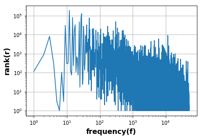

```python
import nltk
from nltk.corpus import gutenberg
from nltk.probability import FreqDist
import matplotlib
import matplotlib.pyplot as plt
matplotlib.use('TkAgg')
fd = FreqDist()
for text in gutenberg.fileids():
    for word in gutenberg.words(text):
        fd[word] += 1
ranks = []
freqs = []
for rank, word in enumerate(fd):
    ranks.append(rank+1)
    freqs.append(fd[word])
plt.loglog(ranks, freqs)
plt.xlabel('frequency(f)', fontsize=14, fontweight='bold')
plt.ylabel('rank(r)', fontsize=14, fontweight='bold')
plt.grid(True)
plt.show()
```

# Similarity measures

There are many similarity measures that can be used for performing NLP tasks. The nltk.metrics package in NLTK is used to provide various evaluation or similarity measures, which is conducive to perform various NLP tasks. In order to test the performance of taggers, chunkers, and so on, in NLP, the standard scores retrieved from information retrieval can be used

```python
from __future__ import print_function
from nltk.metrics import *
training='PERSON OTHER PERSON OTHER OTHER ORGANIZATION'.split()
testing='PERSON OTHER OTHER OTHER OTHER OTHER'.split()
print(accuracy(training,testing))
```

```
0.6666666666666666
```

```python
train_set=set(training)
test_set=set(testing)
precision(train_set,test_set)
```

```
1.0
```

```python
print(recall(train_set,test_set))
```

```
0.6666666666666666
```

```python
print(f_measure(train_set,test_set))
```

```
0.8
```

# Applying similarity measures using Ethe edit distance algorithm

Edit distance or the Levenshtein edit distance between two strings is used to compute the number of characters that can be inserted, substituted, or deleted in order to make two strings equal.

```python
from nltk.metrics import *
edit_distance("relate","relation")
```

```
3
```

```python
edit_distance("suggestion","calculation")
```

```
7
```

```python
edit_distance("sunil","sunilkumar")
```

```
5
```

Here, when we calculate the edit distance between relate and relation, three operations (one substitution and two insertions) are performed. While calculating the edit distance between suggestion and calculation, seven operations (six substitutions and one insertion) are performed.

# Applying similarity measures using Jaccard's Coefficient

Jaccard's coefficient, or Tanimoto coefficient, may be defined as a measure of the overlap of two sets, X and Y.

```python
X=set([50,10])
Y=set([20,10])
print(jaccard_distance(X,Y))
```

```
0.6666666666666666
```

# Applying similarity measures using the Smith Waterman distance

The Smith Waterman distance is similar to edit distance. This similarity metric was developed in order to detect the optical alignments between related protein sequences and DNA. It consists of costs to be assigned to and functions for alphabet mapping to cost values (substitution); cost is also assigned to gap G (insertion or deletion)

# Summary

In this chapter, you have learned various operations that can be performed on a text that is a collection of strings. You have understood the concept of tokenization, substitution, and normalization, and applied various similarity measures to strings using NLTK. We have also discussed Zipf's law, which may be applicable to some of the existing documents. In the next chapter, we'll discuss various language modeling techniques and different NLP tasks.